# Competitive Market Equilibrium

Lecture 4

Div Bhagia

# Quick Review

## Consumer Optimization

Consumers maximize utility subject to a budget constraint:
$$\max_{x,y} U(x,y) \quad \text{s.t.} \quad p_x x + p_y y = I$$

**Solution**: $x^*(p_x, p_y, I)$ and $y^*(p_x, p_y, I)$

Gives us individual **demand functions** for goods $x$ and $y$.

## Firm Optimization

Profit maximization for a price-taking firm:
$$\max_q \pi = p \cdot q - C(q)$$

**First-order condition:** $p = MC(q)$

**Short-run supply curve:** Portion of the MC curve above AVC

The firm produces where price equals marginal cost, as long as it covers variable costs.

Gives us the **supply function** for each firm: $q^*(p, r, w)$

## From Individual to Market

**So far:** Individual consumer and firm decisions

**Today:** How do individual decisions aggregate into market outcomes?

- How are market demand and supply constructed?
- What determines equilibrium prices?
- What happens when conditions change?

Study above under the special case of perfectly competitive markets that are characterized by many buyers and sellers, homogeneous products, and free entry/exit in the long run.

# Demand, Supply, and Equilibrium

## Market Demand

Individual $i$ has demand: $x_i(p_x, p_y, I_i)$

**Market demand** is the horizontal sum of individual demands:

$$Q^D(p_x, p_y, I_1, \ldots, I_m) = \sum_{i=1}^{m} x_i(p_x, p_y, I_i)$$

If each individual’s demand is downward sloping, so is market demand

**Shifts in market demand:** Changes in income, prices of related goods, preferences, or number of consumers shift the curve

## Market Demand: Graphical Construction

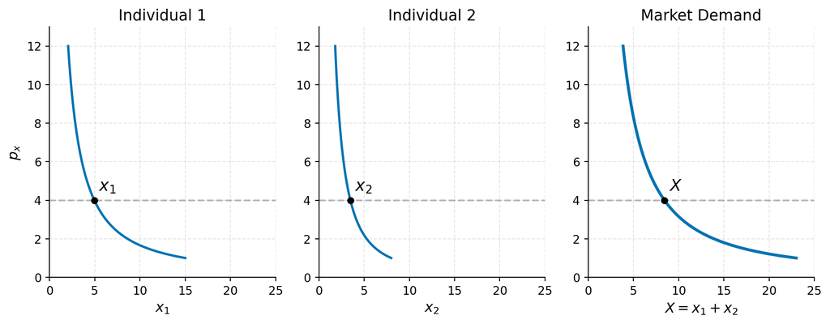

At any price, market quantity is the sum of individual quantities demanded.

## Market Demand Elasticity

$$e_{D,p} = \frac{\partial Q^D}{\partial p} \cdot \frac{p}{Q^D}$$

**Classification:**

- $|e_{D,p}| > 1$: Elastic demand
- $|e_{D,p}| = 1$: Unit elastic
- $|e_{D,p}| < 1$: Inelastic demand

**Why it matters for equilibrium:** The elasticity of demand determines how market prices respond to supply shocks

## Timing of the Supply Response

How quickly can supply adjust?

**Very short run:** Quantity is fixed so only price adjusts (vertical supply curve).

**Short run:** Existing firms adjust output but no entry/exit.

**Long run:** Firms can enter or exit, all inputs are variable.

The distinction matters for policy analysis.

## Short-Run Market Supply

Each firm $j$ has short-run supply $q_j(p, r, w)$

**Market supply** is also a horizontal sum:

$$Q^S(p, r, w) = \sum_{j=1}^{n} q_j(p, r, w)$$

Since each firm’s supply curve slopes upward (rising MC), market supply also slopes upward

**Supply elasticity:**
$$e_{S,p} = \frac{\partial Q^S}{\partial p} \cdot \frac{p}{Q^S} > 0$$

## Market Supply: Graphical Construction

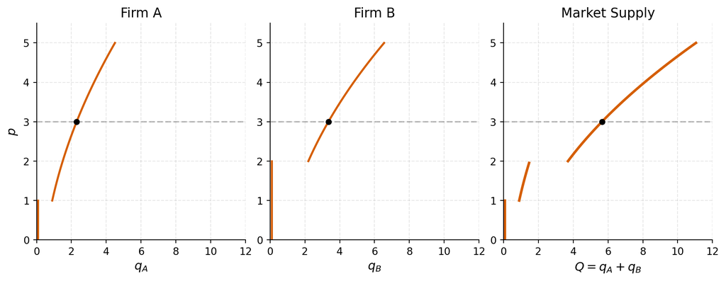

Market supply is the horizontal sum of individual firms’ supply (MC) curves

## Equilibrium

An **equilibrium price** $p^*$ solves:

$$Q^D(p^*) = Q^S(p^*)$$

The equilibrium price serves two functions:

- **Signal to producers:** How much to produce
- **Rationing device:** Allocates goods among consumers

At $p^*$, neither demanders nor suppliers have an incentive to change behavior

## Equilibrium Graphically

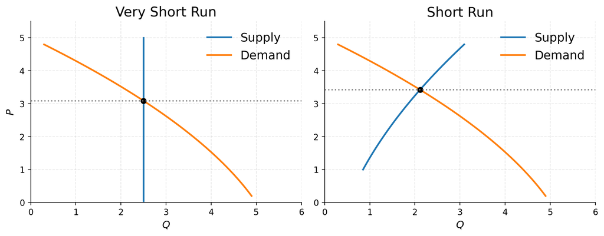

What happens to equilibrium price and quantity if there is an increase in demand?

## Concert Tickets and Surge Pricing

**Very short run in action:**

- Concert venues have fixed capacity (vertical supply)
- A surge in demand → prices must rise to ration seats
- Explains why popular concerts sell out / prices spike on resale markets

**Uber/Lyft surge pricing** works similarly: in the very short run, the number of drivers is nearly fixed, so price surges ration available rides.

**Question:** Is this “fair”?

# Comparative Statics

## Shifts in Supply and Demand

| Demand Curves Shift Because | Supply Curves Shift Because |
| --- | --- |
| Incomes change | Input prices change |
| Prices of substitutes/complements change | Technology changes |
| Preferences change | Number of producers changes |

**Key insight:** The relative magnitudes of price and quantity changes depend on the shapes (elasticities) of the curves

## Supply Shift: Role of Demand Elasticity

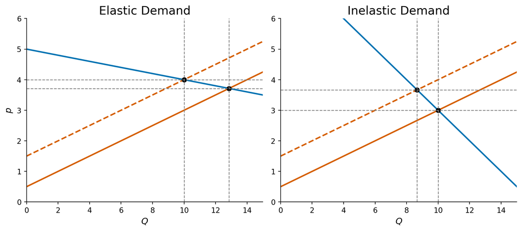

Elastic demand → quantity adjusts more, price less. Inelastic demand → price absorbs most of the shock.

## A Comparative Statics Model

**Demand:** $Q^D = D(p, \alpha)$ where $\alpha$ shifts demand

**Supply:** $Q^S = S(p, \beta)$ where $\beta$ shifts supply

**Equilibrium:** $D(p^*, \alpha) = S(p^*, \beta)$

Differentiate with respect to $\alpha$:

$$D_p \cdot \frac{dp^*}{d\alpha} + D_\alpha = S_p \cdot \frac{dp^*}{d\alpha}$$

$$\frac{dp^*}{d\alpha} = \frac{D_\alpha}{S_p - D_p} > 0$$

Since $D_p < 0$, $S_p > 0$, and $D_\alpha > 0$ (demand increase), equilibrium price rises

## In Elasticity Form

Using expression from last slide:
$$e_{p, \alpha} = \frac{dp^*}{d\alpha} \cdot \frac{\alpha}{p} = \frac{D_\alpha}{S_p - D_p} \cdot \frac{\alpha}{p} = \frac{D_\alpha}{S_p - D_p} \cdot \frac{\alpha/Q^*}{p/Q^*} = \frac{e_{D,\alpha}}{e_{S,p} - e_{D,p}}$$

Note that $\dfrac{d Q^*}{d\alpha} = S_p \cdot \dfrac{dp^*}{d\alpha}$, we can write:

$$e_{Q^*, \alpha} = \frac{dQ^*}{d\alpha} \cdot \frac{\alpha}{Q^*} = \frac{e_{S,p} e_{D,\alpha}}{e_{S,p} - e_{D,p}}$$

This is a useful framework as we can estimate elasticities from data and predict how shocks will affect prices and quantities.

**Intuition**?

# Long-Run Equilibrium

## Key Assumptions for the Long Run

**Entry and exit are free:** No barriers, no special costs

**All inputs are variable:** Firms can adjust capital, labor, everything

**Firms are identical:** Same cost functions, no special resources

**Long-run equilibrium requires:**

- $p = MC$ (profit maximization)
- $p = AC$ (zero economic profit)
- Each firm operates at the minimum of long-run AC

## Why Zero Profits?

If $p > AC$: Economic profits attract entry → supply shifts right → price falls

If $p < AC$: Losses cause exit → supply shifts left → price rises

**Process continues until** $p = \min AC$ and economic profits are exactly zero

**Remember:** Zero economic profit $\neq$ zero accounting profit. Firms still earn a normal return on invested capital, they just don’t earn above-normal returns.

## Shape of the Long-Run Supply Curve

The long-run supply curve depends on what happens to costs as firms enter:

- **Constant cost industry:** Entry doesn’t affect input prices → $LS$ is horizontal
- **Increasing cost industry:** Entry bids up input prices → $LS$ slopes upward
- **Decreasing cost industry:** Entry lowers costs (agglomeration, thicker labor markets) → $LS$ slopes downward

## Increasing Cost Industry

**Why might entry increase costs?**

- New and existing firms compete for scarce inputs (specialized labor, raw materials)
- Expansion may impose external costs (congestion, environmental)
- Growing demand for tax-financed services

**Result:** Long-run equilibrium price rises with industry output

**Example:** Housing construction in a growing city, as more homes are built, land prices and construction labor costs are bid up

## Decreasing Cost Industry

**Why might entry decrease costs?**

- Larger pool of trained labor (thicker labor markets)
- Critical mass of industrialization enables specialized suppliers
- Better transportation and communication networks

**Example:** Silicon Valley, clustering of tech firms reduced costs for all through knowledge spillovers, specialized suppliers, and deep labor pools

**Result:** Long-run supply slopes downward (expansion makes production cheaper)

# Producer Surplus and Rents

## Producer Surplus in the Long Run

**Producer surplus:** Area below market price and above supply curve

- In the **constant cost** case: long-run supply is horizontal → producer surplus is zero
- In the **increasing cost** case: supply slopes upward → positive producer surplus

**Key question:** Who captures these rents? Must look at the input markets to find the ultimate beneficiaries.

## Ricardian Rent

**David Ricardo’s insight (1817):** Land of varying fertility

- At low prices, only the most fertile land is farmed
- As demand grows, less fertile (higher cost) land is brought into production
- Owners of the most fertile land earn **rents** i.e. returns above what’s needed to keep their land in production

The long-run supply curve slopes upward because of these differences in costs across producers

## Capitalization of Rents

In practice, Ricardian rents get **capitalized into input prices**

- More fertile farmland sells at higher prices
- Well-located commercial real estate commands higher rents
- Experienced workers in high-demand fields earn wage premiums

**Implication:** Once rents are capitalized, even low-cost firms may appear to earn zero economic profit and the “advantage” is reflected in the price they paid for the input

# Welfare Analysis

## Consumer and Producer Surplus

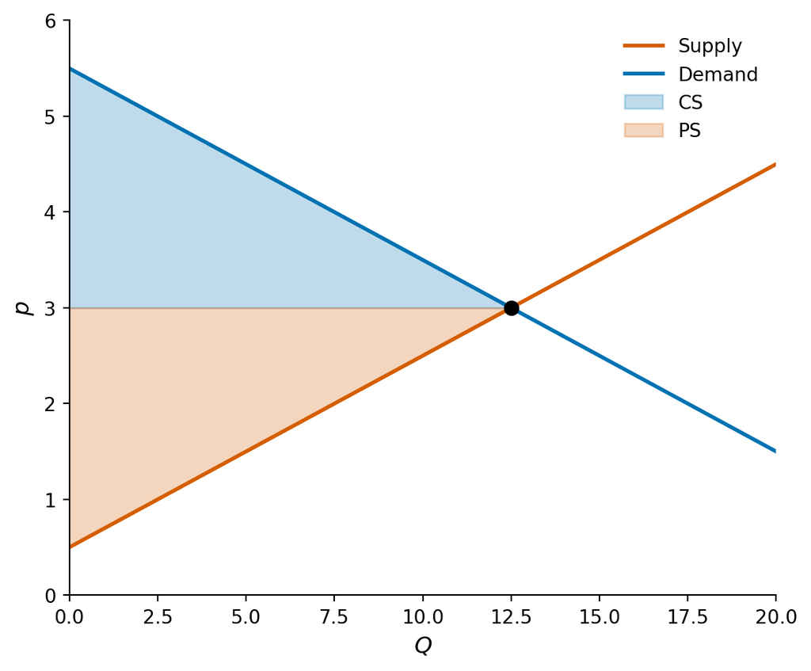

**Total surplus** = CS + PS is maximized at the competitive equilibrium

## Competitive Equilibrium Surplus

The social planner’s problem: choose $Q$ to maximize

$$W(Q) = \underbrace{\int_0^Q D(q) \, dq}_{\text{Total value to consumers}} - \underbrace{\int_0^Q S(q) \, dq}_{\text{Total cost of production}}$$

First-order condition: $D(Q^*) = S(Q^*)$, which is exactly the competitive equilibrium condition!

**Competitive markets get it right:** Decentralized decisions by price-taking agents maximize total surplus. Caveat?

## Deadweight Loss

Any departure from the competitive outcome creates **deadweight loss** (DWL) i.e. surplus that is lost and captured by no one.

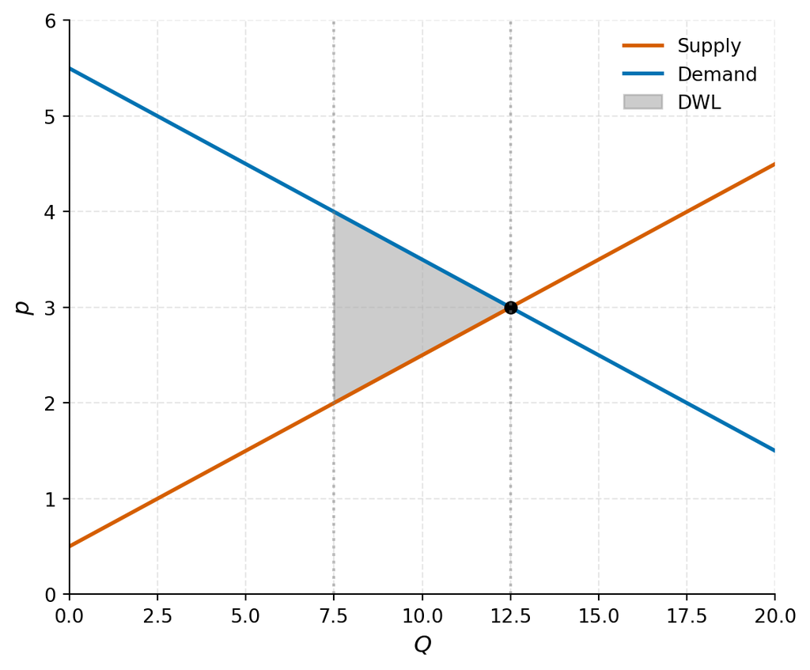

# Policy Applications

## Price Controls and Shortages

Setting a price ceiling below equilibrium:

- Creates a **shortage**: $Q^D > Q^S$ at the controlled price
- **Transfer** from producers to consumers who get to buy at the lower price
- **Deadweight loss** from forgone transactions

**Example:** Rent control, tenants who find apartments benefit, but some units are withdrawn from the market and some potential renters can’t find housing

## Tax Incidence

A per-unit tax $t$ creates a wedge between what buyers pay and sellers receive:

$$p^D = p^S + t$$

**Who bears the tax?** Depends on relative elasticities:

$$\frac{dP^D/dt}{dP^S/dt} = -\frac{e_{S,p}}{e_{D,p}}$$

**Rule of thumb:** The more inelastic side of the market bears more of the tax

- If demand is inelastic (necessities) → consumers bear most of the tax
- If supply is inelastic (fixed factors) → producers bear most of the tax

## Deadweight Loss of Taxation

All non-lump-sum taxes involve deadweight losses. A linear approximation:

$$DWL \approx -\frac{1}{2} \cdot \frac{e_{S,p} \cdot e_{D,p}}{e_{S,p} - e_{D,p}} \cdot \frac{t^2}{p} \cdot Q$$

**Three key insights:**

- DWL is proportional to the **square** of the tax rate — doubling the tax more than doubles the welfare cost
- Higher elasticities → larger DWL (more behavioral distortion)
- Efficient taxation: spread taxes across many goods with low rates rather than taxing one good heavily (Ramsey rule intuition)

## Who Pays the Payroll Tax?

The U.S. payroll tax (Social Security + Medicare) is nominally split 50-50 between employers and employees

**But economic incidence depends on labor supply elasticity:**

- Labor supply is relatively inelastic (people need to work)
- So workers bear most of the tax, regardless of the statutory split
- Employer’s “share” is largely passed through as lower wages

**Empirical evidence** (Gruber 1997, Saez et al. 2012) confirms: the incidence falls primarily on workers